# Distribution of annotations in metagenomes

This tutorial discusses specialized versions of the generic functions `barchart()` and `boxplot()`. The latter is part of the matR package but `barchart.biom()` is an extension using the ggplot2 package, so this preparation is needed to apply it:

```r
library(matR)
library(ggplot2)        # should require() within barchart.biom()
#source("http://mg-rast.github.io/matR/local-workbench.R")
barchart.biom <- function (...) { }
source("http://braithwaite.github.io/matR/local-workbench.R")
```

Below, a `biom` object of several metagenomes is created for demonstration, and then a barchart summarizing taxonomic content across the top hierarchy level.

```r
writeLines (colnames (xx1), "my_ids.txt")
zz <- biomRequest (file="my_ids.txt", request="organism", group_level="phylum")
barchart.biom (zz, raw=FALSE)
```

[output not shown]

Annotations displayed in the plot can be restricted.

```r
barchart.biom (zz, "Bacteria", raw=FALSE)
```

[output not shown]

And again, for a still more focused view.

```r
barchart.biom (zz, c("Bacteria","Firmicutes"), raw=FALSE)
```

[output not shown]

The function `boxplot.biom()` summarizes the annotation count distribution of each metagenome. First, here is a boxplot of the log transformed counts.

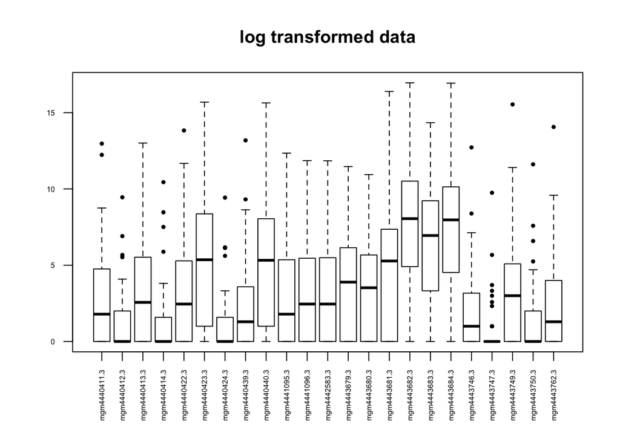

```r
xx2t <- transform (xx2, t_Log)           # revise
boxplot (xx2t, main="log transformed data", notch=FALSE)
```

It’s possible to display two plots in the same frame, as in the next example to assist comparison of raw and transformed counts. Adjacent plots illustrate how effectively (or not) transformation aligns count distributions that may vary greatly. Also note how values of the “material” metadata field are used to assigned colors.

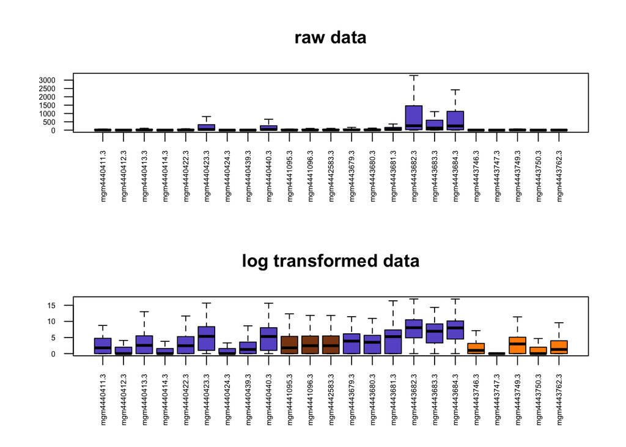

```r
boxplot (xx2, xx2t, x.main="raw data", y.main="log transformed data", map=c(col="material"), notch=FALSE,
  col=c("freshwater"="slateblue", "hot spring"="chocolate4", "hot spring ; microbial mat"="darkorange"),
  outline=FALSE)
```

Here outliers were simply ignored due to `outline=FALSE` but they deserve, of course, careful attention. Mapping metadata to graphical parameters, as above with `map=`, is described in the principal components tutorial in more detail. Below, the prefix `$$` effects a literal substitution of metadata, labeling the axis with sample names.

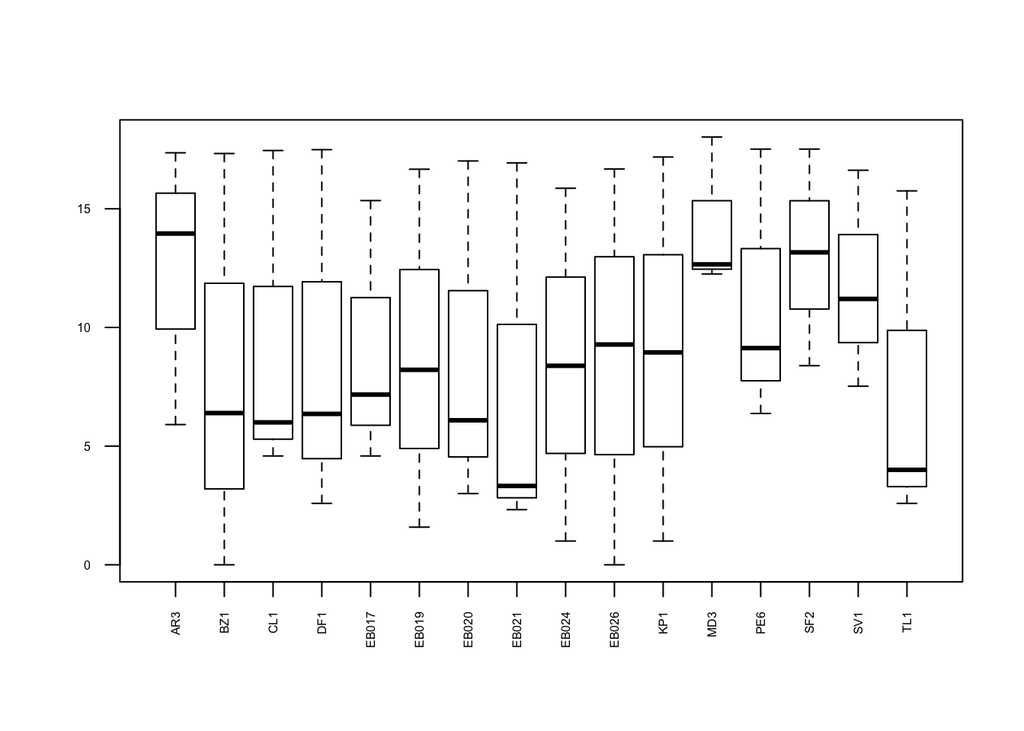

```r
boxplot (transform (xx4, t_Log), names="$$sample.data.sample_name", notch=FALSE)
```

A juxtaposition of two plots, rather than show raw and normalized counts as above, may also present two different normalizations.

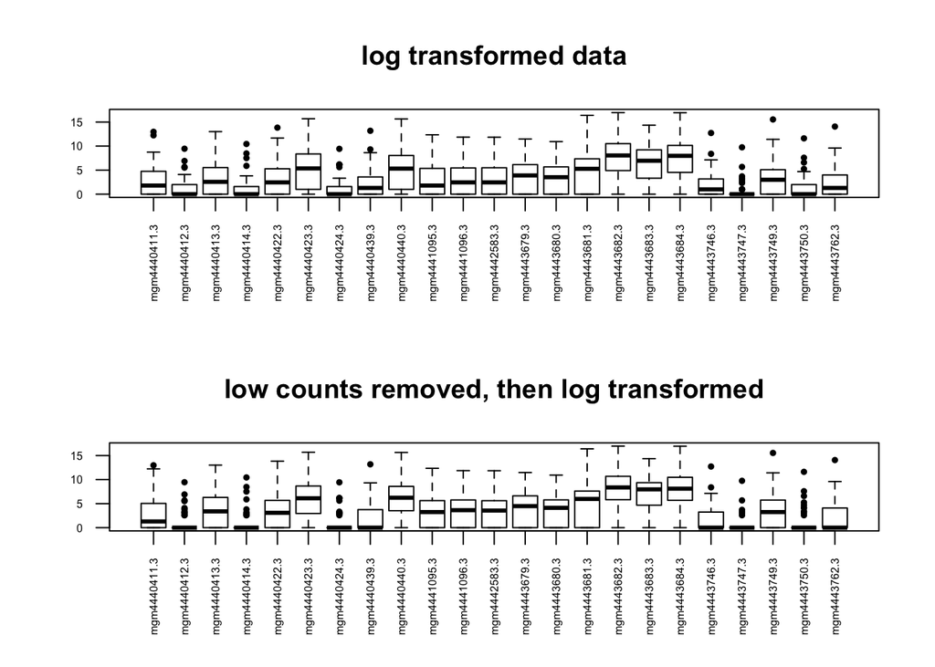

```r
xx2tt <- transform (xx2, t_Threshold=list(entry.min=5), t_Log)
boxplot (xx2t, xx2tt, notch=FALSE, x.main="log transformed data", y.main="low counts removed, then log transformed")
```

This could help choose a normalization procedure and tune its parameters.